# Experiments for accuracy varying various hyper-parameters

### Defining various Experiments.

### List of Experiments hold each value as a list of # of Experiments, # of hidden units, learning rate

```python
from Network import callable
import numpy as np
import matplotlib.pyplot as plt

exp_all = []
exp_all.append([30,10,1.0])
exp_all.append([30,20,1.0])
exp_all.append([30,30,1.0])
exp_all.append([30,10,2.0])
exp_all.append([30,10,3.0])
exp_all.append([30,20,2.0])
exp_all.append([30,20,3.0])
exp_all.append([30,30,2.0])
exp_all.append([30,30,3.0])
```

### Run code for various value combination of hyper-parameter and plot graph between number of epochs and accuracy

```
Epoch 29: 9229 / 10000
```

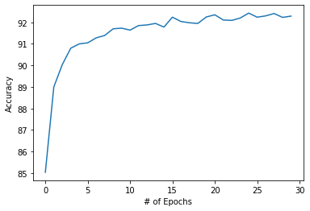

```
Epoch 29: 9344 / 10000
```

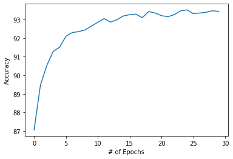

```
Epoch 29: 9490 / 10000
```

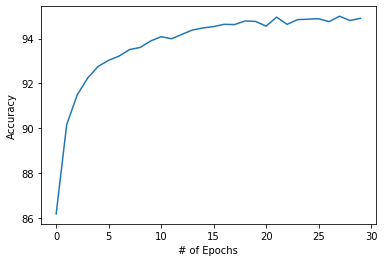

```
Epoch 29: 9253 / 10000
```

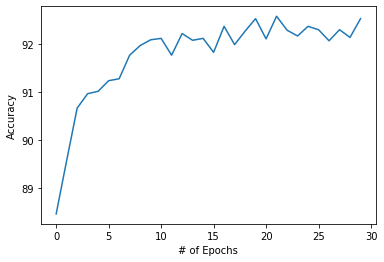

```
Epoch 29: 9121 / 10000
```

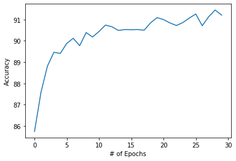

```
Epoch 29: 9434 / 10000
```

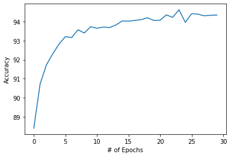

```
Epoch 29: 9383 / 10000
```

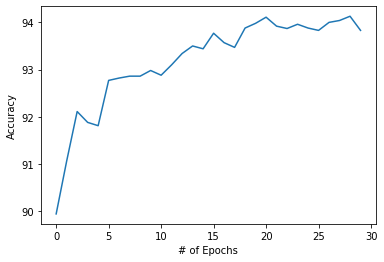

```
Epoch 29: 9474 / 10000
```

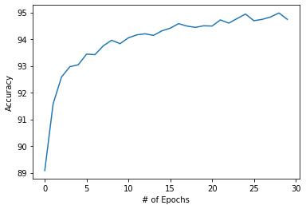

```
Epoch 29: 9464 / 10000
```

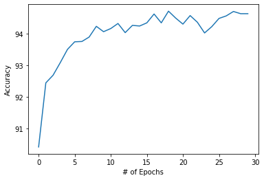

```python
all_exp_accuracy = []
for exp in exp_all:
    n_epochs = exp[0]
    hidden_units = exp[1]
    eta = exp[2]
    final_Accuracy = callable(n_epochs, hidden_units, eta)
    all_exp_accuracy.append(final_Accuracy)
```

### Collect all accuracys at the end of each experiment for the last epoch and develop a graph between learning rate and accuracy

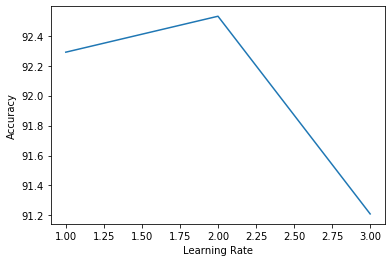

```python
alpha = [1.,2.,3.]
alpha_accuracy = [all_exp_accuracy[0],all_exp_accuracy[3],all_exp_accuracy[4]]
plt.plot(alpha,alpha_accuracy)
plt.xlabel('Learning Rate')
plt.ylabel('Accuracy')
plt.show()
```

Here we notice, as the learning rate is increased, accuracy increases. However, with further rise in learning rate, accuracy drops a lot. This is because, with higher value of learning rate, system misses the global minima and further starts rising in the graph.

### Collect all accuracys at the end of each experiment for the last epoch and develop a graph between number of neurons in hidden layer and accuracy

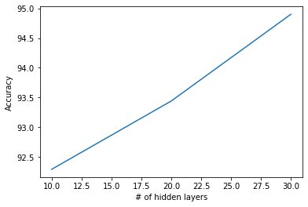

```python
n_hidden_units = [10,20,30]
neuron_accuracy = [all_exp_accuracy[0],all_exp_accuracy[1],all_exp_accuracy[2]]
plt.plot(n_hidden_units,neuron_accuracy)
plt.xlabel('# of hidden layers')
plt.ylabel('Accuracy')
plt.show()
```

Here we notice, as the number of neurons in hidden layer increases, accuracy increases. This is because the system is growing in depth and multiplies the feauture computation.

## With following configurations:

### Configuration: 30-epochs, 30 hidden-units, 3.0 eta

#### On running the model 3-times, we get following values of accuracy

1st run: Epoch 29: 9477 / 10000

2nd run: Epoch 29: 9489 / 10000

3rd run: Epoch 29: 9504 / 10000

## We can further improve the prediction rate by increasing number of hidden layers so that computation can be increased on each pixel of the image and we get better accuracy.